# Group A — Yogurt Study Data Dictionary

Understanding every column in the dataset

## Overview

This document describes every CSV file in the **Group A (yogurt study)** dataset. There are four files, linked together by participant IDs (`pid`) and sample IDs (`sample_id`).

```r
library(tidyverse)

# Helper to read CSVs cleanly
read_data <- function(path) {
  read_csv(file.path("../../data/group_a_yogurt", path), show_col_types = FALSE)
}
```

## File 0 — Sample IDs (`00_sample_ids_yogurt.csv`)

```r
sample_ids <- read_data("00_sample_ids_yogurt.csv")
sample_ids
```

```
# A tibble: 102 × 4
   pid    time_point       arm            sample_id
   <chr>  <chr>            <chr>          <chr>
 1 pid_25 baseline         unchanged_diet UNCH001
 2 pid_51 baseline         yogurt         YOG002
 3 pid_33 baseline         yogurt         YOG003
 4 pid_13 baseline         yogurt         YOG004
 5 pid_37 after_antibiotic unchanged_diet UNCH005
 6 pid_09 after_antibiotic unchanged_diet UNCH006
 7 pid_51 after_antibiotic yogurt         YOG007
 8 pid_24 baseline         unchanged_diet UNCH008
 9 pid_12 after_antibiotic yogurt         YOG009
10 pid_36 baseline         unchanged_diet UNCH010
# ℹ 92 more rows
```

### What one row represents

**One biological sample** collected from a participant at a specific time point. Each of the 51 participants contributes **two** samples (baseline + after antibiotic), for a total of 102 rows.

### Columns

| Column | Type | What it means |
| --- | --- | --- |
| `pid` | chr | Participant ID — links to the metadata table (File 1) |
| `time_point` | chr | When the sample was collected — either `baseline` or `after_antibiotic` |
| `arm` | chr | Which group the participant was assigned to — `yogurt` or `unchanged_diet` |
| `sample_id` | chr | Unique sample code — links to the qPCR (File 2) and Luminex (File 3) tables |

```r
# How many samples per time point and arm?
sample_ids |>
  count(time_point, arm)
```

```
# A tibble: 4 × 3
  time_point       arm                n
  <chr>            <chr>          <int>
1 after_antibiotic unchanged_diet    25
2 after_antibiotic yogurt            26
3 baseline         unchanged_diet    25
4 baseline         yogurt            26
```

## File 1 — Participant Metadata (`01_participant_metadata_yogurt.csv`)

```r
metadata <- read_data("01_participant_metadata_yogurt.csv")
metadata
```

```
# A tibble: 51 × 7
   pid    arm            days_since_last_sex birth_control   age education sex
   <chr>  <chr>                        <dbl> <chr>         <dbl> <chr>     <chr>
 1 pid_01 unchanged_diet                   2 no hormonal …    28 grade 10… fema…
 2 pid_02 unchanged_diet                   4 Depoprovera      34 less tha… fema…
 3 pid_03 unchanged_diet                   3 no hormonal …    32 grade 10… fema…
 4 pid_04 yogurt                           1 Depoprovera      30 grade 10… fema…
 5 pid_05 yogurt                           5 Depoprovera      34 less tha… fema…
 6 pid_06 unchanged_diet                   9 no hormonal …    27 grade 10… fema…
 7 pid_07 yogurt                           3 no hormonal …    25 less tha… fema…
 8 pid_08 yogurt                           4 no hormonal …    26 grade 10… fema…
 9 pid_09 unchanged_diet                  10 Depoprovera      34 grade 10… fema…
10 pid_10 yogurt                           7 Depoprovera      32 post-sec… fema…
# ℹ 41 more rows
```

### What one row represents

**One participant** (a woman enrolled in the study). There are 51 participants.

### Columns

| Column | Type | What it means |
| --- | --- | --- |
| `pid` | chr | Participant ID — links to the sample IDs table |
| `arm` | chr | Group assignment — `yogurt` or `unchanged_diet` (26 yogurt, 25 unchanged) |
| `days_since_last_sex` | num | Number of days since the participant’s most recent sexual activity (range: 1–48) |
| `birth_control` | chr | Type of birth control used — `no hormonal birth control` or `Depoprovera` |
| `age` | num | Age in years (range: 24–37) |
| `education` | chr | Highest education level — one of `less than grade 9`, `grade 10-12, matriculated`, `grade 10-12, not matriculated`, or `post-secondary` |
| `sex` | chr | All participants are `female` |

```r
metadata |>
  count(arm, birth_control)
```

```
# A tibble: 4 × 3
  arm            birth_control                 n
  <chr>          <chr>                     <int>
1 unchanged_diet Depoprovera                   8
2 unchanged_diet no hormonal birth control    17
3 yogurt         Depoprovera                  17
4 yogurt         no hormonal birth control     9
```

```r
metadata |>
  summarise(
    n_participants = n(),
    age_min = min(age),
    age_max = max(age),
    age_mean = mean(age),
    days_since_sex_min = min(days_since_last_sex),
    days_since_sex_max = max(days_since_last_sex)
  )
```

```
# A tibble: 1 × 6
  n_participants age_min age_max age_mean days_since_sex_min days_since_sex_max
           <int>   <dbl>   <dbl>    <dbl>              <dbl>              <dbl>
1             51      24      37     30.7                  1                 48
```

```r
metadata |>
  count(education)
```

```
# A tibble: 4 × 2
  education                         n
  <chr>                         <int>
1 grade 10-12, matriculated        10
2 grade 10-12, not matriculated    21
3 less than grade 9                 9
4 post-secondary                   11
```

## File 2 — qPCR Results (`02_qpcr_results_yogurt.csv`)

```r
qpcr <- read_data("02_qpcr_results_yogurt.csv")
qpcr
```

```
# A tibble: 102 × 4
   sample_id qpcr_bacteria qpcr_crispatus qpcr_iners
   <chr>             <dbl>          <dbl>      <dbl>
 1 UNCH092        3093064.            0         26.8
 2 UNCH042           8275.            0         76.0
 3 UNCH015        7532202.            0        555.
 4 UNCH035        4794320.           13.0   204309.
 5 UNCH019        5328344.            0     107806.
 6 UNCH040           5804.            0     121045.
 7 YOG083        11559331.            0         89.1
 8 YOG030          160947.           38.6  1555847.
 9 YOG059        13493009             0        211.
10 YOG050          142850.         1119.   3854097.
# ℹ 92 more rows
```

### What one row represents

**Quantitative PCR measurements for one sample.** There are 102 rows — one per sample.

### Columns

| Column | Type | What it means |
| --- | --- | --- |
| `sample_id` | chr | Sample code — links to the sample IDs table |
| `qpcr_bacteria` | num | Total bacterial load measured by qPCR (16S rRNA gene copies) |
| `qpcr_crispatus` | num | Abundance of *Lactobacillus crispatus* (a beneficial vaginal bacterium) |
| `qpcr_iners` | num | Abundance of *Lactobacillus iners* (another *Lactobacillus* species common in the vaginal microbiome) |

```r
# Join with sample IDs to see which arm each qPCR result belongs to
qpcr_with_arm <- sample_ids |>
  select(sample_id, time_point, arm) |>
  inner_join(qpcr, by = "sample_id")

qpcr_with_arm |>
  group_by(time_point, arm) |>
  summarise(
    n = n(),
    mean_total_bacteria = mean(qpcr_bacteria),
    mean_crispatus = mean(qpcr_crispatus),
    mean_iners = mean(qpcr_iners),
    .groups = "drop"
  )
```

```
# A tibble: 4 × 6
  time_point       arm           n mean_total_bacteria mean_crispatus mean_iners
  <chr>            <chr>     <int>               <dbl>          <dbl>      <dbl>
1 after_antibiotic unchange…    25             926783.     322465.       498296.
2 after_antibiotic yogurt       26             565014.      64290.       647384.
3 baseline         unchange…    25           16359934.         80.5        7963.
4 baseline         yogurt       26           19498560.          0.334     11038.
```

## File 3 — Luminex Cytokine Results (`03_luminex_results_yogurt.csv`)

```r
luminex <- read_data("03_luminex_results_yogurt.csv")
luminex
```

```
# A tibble: 1,020 × 4
   sample_id cytokine     conc limits
   <chr>     <chr>       <dbl> <chr>
 1 UNCH092   IL-1a      5.85   within limits
 2 UNCH092   IL-10      0.767  out of range
 3 UNCH092   IL-1b      0.250  out of range
 4 UNCH092   IL-8       7.92   within limits
 5 UNCH092   IL-6       0.0935 out of range
 6 UNCH092   TNFa       0.471  out of range
 7 UNCH092   IP-10    177.     within limits
 8 UNCH092   MIG      370.     within limits
 9 UNCH092   IFN-Y      0.344  out of range
10 UNCH092   MIP-3a    32.8    within limits
# ℹ 1,010 more rows
```

### What one row represents

**One cytokine measurement for one sample.** The table is in **long (tidy) format**: each row is a single concentration value. There are 10 cytokines × 102 samples = 1020 rows.

### Columns

| Column | Type | What it means |
| --- | --- | --- |
| `sample_id` | chr | Sample code — links to the sample IDs table |
| `cytokine` | chr | Name of the cytokine or chemokine measured — one of: `IL-1a`, `IL-1b`, `IL-6`, `IL-8`, `IL-10`, `TNFa`, `IFN-Y`, `IP-10`, `MIG`, `MIP-3a` |
| `conc` | num | Concentration of that cytokine (units depend on the assay, e.g. pg/mL) |
| `limits` | chr | Whether the concentration falls within the detectable range — `within limits` or `out of range` |

```r
# How many samples per cytokine, and how many are out of range?
luminex |>
  count(cytokine, limits) |>
  pivot_wider(names_from = limits, values_from = n)
```

```
# A tibble: 10 × 3
   cytokine `out of range` `within limits`
   <chr>             <int>           <int>
 1 IFN-Y               101               1
 2 IL-10               102              NA
 3 IL-1a                NA             102
 4 IL-1b                74              28
 5 IL-6                 77              25
 6 IL-8                  4              98
 7 IP-10                 3              99
 8 MIG                  13              89
 9 MIP-3a               24              78
10 TNFa                100               2
```

```r
# Join with arm info and summarise
luminex_with_arm <- sample_ids |>
  select(sample_id, time_point, arm) |>
  inner_join(luminex, by = "sample_id")

luminex_with_arm |>
  group_by(time_point, arm, cytokine) |>
  summarise(
    mean_conc = mean(conc, na.rm = TRUE),
    .groups = "drop"
  ) |>
  slice_max(mean_conc, n = 5)
```

```
# A tibble: 5 × 4
  time_point       arm            cytokine mean_conc
  <chr>            <chr>          <chr>        <dbl>
1 after_antibiotic yogurt         MIG          7178.
2 after_antibiotic unchanged_diet MIG          2509.
3 baseline         unchanged_diet MIG          2243.
4 baseline         yogurt         MIG          1201.
5 after_antibiotic yogurt         IP-10         723.
```

## How the files connect

Here is a diagram of how the four tables relate to each other:

```
 ┌─────────────────────┐
 │ File 0: sample_ids  │ ◄── pid ────┐
 │  (102 rows, 4 cols) │             │
 └─────┬──────┬───────┘             │
       │      │                      │
  sample_id  sample_id               │
       │      │                      │
       ▼      ▼                      │
 ┌─────────┐ ┌──────────────┐  ┌────┴──────────────────┐
 │ File 2: │ │ File 3:      │  │ File 1: metadata       │
 │ qPCR    │ │ Luminex      │  │ (51 rows, 7 cols)      │
 │ (102 r) │ │ (1020 r)     │  │                         │
 └─────────┘ └──────────────┘  └─────────────────────────┘
```

- **File 1** holds one row per **participant** (51 participants).
- **File 0** links participants to their samples (2 samples each → 102 rows).
- **Files 2 and 3** hold lab measurements keyed by `sample_id`.

```r
# One big joined table for exploration
all_data <- sample_ids |>
  left_join(metadata, by = c("pid", "arm")) |>
  left_join(qpcr, by = "sample_id") |>
  left_join(luminex, by = "sample_id")

glimpse(all_data)
```

```
Rows: 1,020
Columns: 15
$ pid                 <chr> "pid_25", "pid_25", "pid_25", "pid_25", "pid_25", …
$ time_point          <chr> "baseline", "baseline", "baseline", "baseline", "b…
$ arm                 <chr> "unchanged_diet", "unchanged_diet", "unchanged_die…
$ sample_id           <chr> "UNCH001", "UNCH001", "UNCH001", "UNCH001", "UNCH0…
$ days_since_last_sex <dbl> 8, 8, 8, 8, 8, 8, 8, 8, 8, 8, 2, 2, 2, 2, 2, 2, 2,…
$ birth_control       <chr> "no hormonal birth control", "no hormonal birth co…
$ age                 <dbl> 27, 27, 27, 27, 27, 27, 27, 27, 27, 27, 36, 36, 36…
$ education           <chr> "grade 10-12, not matriculated", "grade 10-12, not…
$ sex                 <chr> "female", "female", "female", "female", "female", …
$ qpcr_bacteria       <dbl> 13493009, 13493009, 13493009, 13493009, 13493009, …
$ qpcr_crispatus      <dbl> 0, 0, 0, 0, 0, 0, 0, 0, 0, 0, 0, 0, 0, 0, 0, 0, 0,…
$ qpcr_iners          <dbl> 8.240, 8.240, 8.240, 8.240, 8.240, 8.240, 8.240, 8…
$ cytokine            <chr> "IL-1a", "IL-10", "IL-1b", "IL-8", "IL-6", "TNFa",…
$ conc                <dbl> 24.5500, 0.7670, 1.2800, 225.6100, 0.3500, 0.4710,…
$ limits              <chr> "within limits", "out of range", "within limits", …
```

## Glossary of abbreviations

| Abbreviation | Full meaning |
| --- | --- |
| qPCR | Quantitative polymerase chain reaction — a lab method to measure DNA amounts |
| *L. crispatus* | *Lactobacillus crispatus* — a bacterium linked to healthy vaginal microbiomes |
| *L. iners* | *Lactobacillus iners* — another common vaginal *Lactobacillus* species |
| Luminex | A bead-based assay that measures many proteins (like cytokines) at once |
| Cytokine | A small signalling protein released by immune cells |
| Chemokine | A type of cytokine that attracts immune cells to a site of infection |
| IL | Interleukin (a family of cytokines) |
| TNFa | Tumour necrosis factor alpha (a cytokine involved in inflammation) |
| IFN-Y | Interferon gamma (a cytokine important for immune defence) |
| IP-10 | Interferon gamma-induced protein 10 (a chemokine) |
| MIG | Monokine induced by gamma interferon (a chemokine) |
| MIP-3a | Macrophage inflammatory protein 3 alpha (a chemokine) |
| Depoprovera | A hormonal injectable contraceptive (medroxyprogesterone acetate) |

## Table 1 — Participant characteristics by study arm

A **Table 1** is the standard way to start a medical or epidemiology paper: it shows the characteristics of participants side-by-side by treatment group, so readers can see if the groups are well-balanced.

Here we use `gtsummary::tbl_summary()` to summarise the participant metadata by arm (yogurt vs unchanged diet), then `add_p()` to test whether any differences could be due to chance alone. A p-value < 0.05 suggests a real difference between the groups.

```r
library(gtsummary)

metadata |>
  select(-pid, -sex) |>     # drop the ID column and the constant \`sex\` column
  tbl_summary(
    by = arm,               # summarise each column, split by study arm
    statistic = list(age ~ "{mean} ({sd})")  # age: mean (SD) instead of median (IQR)
  ) |>
  add_p(
    test = list(age ~ "t.test")              # age: t-test instead of Wilcoxon
  )
```

| **Characteristic** | **unchanged_diet** N = 25<sup>1</sup> | **yogurt** N = 26<sup>1</sup> | **p-value**<sup>2</sup> |
| --- | --- | --- | --- |
| days_since_last_sex | 6 (3, 10) | 5 (3, 11) | 0.8 |
| birth_control |  |  | 0.017 |
| Depoprovera | 8 (32%) | 17 (65%) |  |
| no hormonal birth control | 17 (68%) | 9 (35%) |  |
| age | 30.4 (3.3) | 31.0 (3.3) | 0.5 |
| education |  |  | 0.8 |
| grade 10-12, matriculated | 6 (24%) | 4 (15%) |  |
| grade 10-12, not matriculated | 9 (36%) | 12 (46%) |  |
| less than grade 9 | 4 (16%) | 5 (19%) |  |
| post-secondary | 6 (24%) | 5 (19%) |  |

<sup>1</sup> Median (Q1, Q3); n (%); Mean (SD)  
<sup>2</sup> Wilcoxon rank sum test; Pearson’s Chi-squared test; Welch Two Sample t-test; Fisher’s exact test

### What to look for

- **N (%)** rows for categorical variables like `birth_control` and `education`.
- **Mean (SD)** or **Median (IQR)** rows for continuous variables like `age` and `days_since_last_sex` (gtsummary automatically picks the right summary).
- The **p-value** column tells you whether the yogurt group and the unchanged-diet group differ significantly on that variable. If all p-values are large (> 0.05), the randomisation worked well.

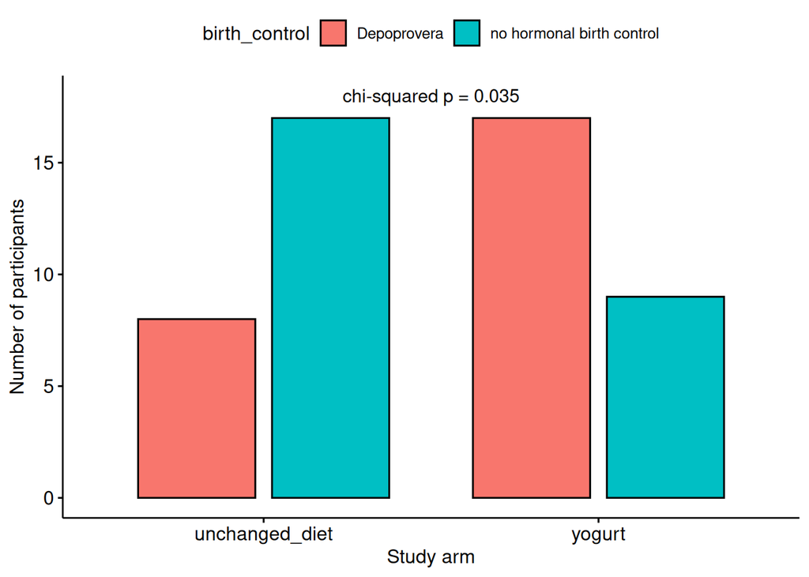

Figure 1: Birth control use in each study arm. p-value from a chi-squared test.

```r
library(ggpubr)

# Chi-squared test on the arm × birth_control table
chisq <- chisq.test(table(metadata$arm, metadata$birth_control))

# Build the bar plot — counts of each birth control type, side-by-side by arm
metadata |>
  count(arm, birth_control) |>
  ggbarplot(
    x = "arm",
    y = "n",
    fill = "birth_control",
    position = position_dodge(0.8),
    xlab = "Study arm",
    ylab = "Number of participants"
  ) +
  annotate("text",
    x = 1.5, y = max(table(metadata$arm, metadata$birth_control) + 1),
    label = paste0("chi-squared p = ", round(chisq$p.value, 3)),
    size = 4
  )
```

Because `birth_control` is a **categorical** variable, a Wilcoxon test doesn’t apply here. Instead we use a **chi-squared test**, which checks whether the proportion of Depoprovera users is the same in the yogurt and unchanged-diet arms.

## Research question — Effect of yogurt on the vaginal microbiome after antibiotics

> **Question:** Does eating yogurt (vs. an unchanged diet) help restore a healthier vaginal microbiome after antibiotic treatment?

To answer this, we look at qPCR measurements of three things:

- **Total bacteria** — overall bacterial load
- *L. crispatus* — a bacterium linked to a healthy vaginal microbiome
- *L. iners* — another common *Lactobacillus* species

We compare **yogurt** vs. **unchanged diet** at each time point (baseline and after antibiotic). The plots below show abundance on a log scale (adding 1 to handle zeros). A **Wilcoxon rank-sum test** is used to compare the two groups at each time point — non-significant p-values (ns) suggest that any visible difference could just be due to chance.

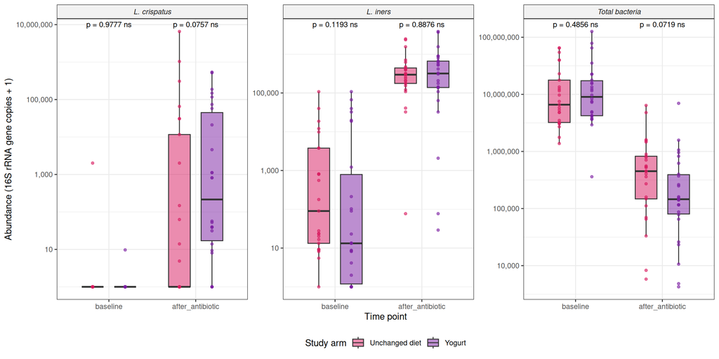

Figure 2: qPCR results faceted by bacterium. Boxplots compare yogurt vs unchanged diet at baseline and after antibiotic treatment. Pink = unchanged diet, purple = yogurt. p-values from Wilcoxon rank-sum test.

```r
library(scales)

# Join qPCR with sample IDs, reshape to long format for faceting
qpcr_long <- sample_ids |>
  inner_join(qpcr, by = "sample_id") |>
  pivot_longer(
    cols = c(qpcr_bacteria, qpcr_crispatus, qpcr_iners),
    names_to = "bacterium",
    values_to = "abundance"
  ) |>
  mutate(
    bacterium = recode(bacterium,
      qpcr_bacteria = "Total bacteria",
      qpcr_crispatus = "L. crispatus",
      qpcr_iners = "L. iners"
    ),
    time_point = fct_relevel(time_point, "baseline", "after_antibiotic"),
    abundance = abundance + 1
  )

# Compute Wilcoxon p-values for each bacterium × time point
pvals <- qpcr_long |>
  group_by(bacterium, time_point) |>
  summarise(
    p = wilcox.test(abundance ~ arm, data = pick(everything()))$p.value,
    .groups = "drop"
  ) |>
  mutate(
    star = case_when(
      p < 0.001 ~ "***",
      p < 0.01  ~ "**",
      p < 0.05  ~ "*",
      TRUE      ~ "ns"
    ),
    label = paste0("p = ", format(p, digits = 3), " ", star)
  )
# Custom colours: unchanged diet = pink, yogurt = purple
arm_colors <- c("unchanged_diet" = "#D81B60", "yogurt" = "#7B1FA2")

ggplot(qpcr_long, aes(x = time_point, y = abundance)) +
  geom_boxplot(aes(fill = arm), alpha = 0.5, outlier.shape = NA,
               width = 0.5, position = position_dodge(width = 0.75)) +
  geom_point(aes(color = arm),
             position = position_dodge(width = 0.75),
             size = 1.2, alpha = 0.6) +
  facet_wrap(~ bacterium, scales = "free_y") +
  scale_fill_manual(values = arm_colors,
                    labels = c("Unchanged diet", "Yogurt")) +
  scale_color_manual(values = arm_colors, guide = "none") +
  scale_y_log10(labels = comma) +
  labs(x = "Time point",
       y = "Abundance (16S rRNA gene copies + 1)",
       fill = "Study arm") +
  geom_text(
    data = pvals,
    aes(x = time_point, y = Inf, label = label),
    vjust = 1.5, size = 3.2, inherit.aes = FALSE
  ) +
  theme_bw() +
  theme(
    legend.position = "bottom",
    strip.background = element_rect(fill = "grey95"),
    strip.text = element_text(face = "italic")
  )
```

### What to look for

- **Total bacteria:** Are the two arms similar at baseline? Does one group show a bigger drop after antibiotics?
- *L. crispatus*: This “good” bacterium often drops after antibiotics. Does it recover more in the yogurt group?
- *L. iners*: This species can be protective or harmful depending on the context. Does yogurt affect it differently than the unchanged diet?

The p-values above each pair of boxes tell you whether the difference between yogurt and unchanged diet is statistically significant at that time point.

### Export

You can download standalone copies of the table and the figure from the files below. The code chunk saves them using `gtsave()` (for the gtsummary table) and `ggsave()` (for the ggplot / ggpubr figure).

```r
# Create the output folder if it doesn't exist already
dir.create("output", showWarnings = FALSE)

# --- Table 1 as HTML ---

library(gtsummary)
library(gt)  # for gtsave()

t1 <- metadata |>
  select(-pid, -sex) |>
  tbl_summary(
    by = arm,
    statistic = list(age ~ "{mean} ({sd})")
  ) |>
  add_p(
    test = list(age ~ "t.test")
  )

gtsave(as_gt(t1), "output/table-1.html")

# --- Figure 1 as PDF ---

library(ggpubr)

chisq <- chisq.test(table(metadata$arm, metadata$birth_control))

p <- metadata |>
  count(arm, birth_control) |>
  ggbarplot(
    x = "arm",
    y = "n",
    fill = "birth_control",
    position = position_dodge(0.8),
    xlab = "Study arm",
    ylab = "Number of participants"
  ) +
  annotate("text",
    x = 1.5, y = max(table(metadata$arm, metadata$birth_control) + 1),
    label = paste0("chi-squared p = ", round(chisq$p.value, 3)),
    size = 4
  )

ggsave("output/figure-1.pdf", plot = p, width = 6, height = 4)

# --- Figure 2 — qPCR facet plot as PDF ---

library(scales)

qpcr_long <- sample_ids |>
  inner_join(qpcr, by = "sample_id") |>
  pivot_longer(
    cols = c(qpcr_bacteria, qpcr_crispatus, qpcr_iners),
    names_to = "bacterium",
    values_to = "abundance"
  ) |>
  mutate(
    bacterium = recode(bacterium,
      qpcr_bacteria = "Total bacteria",
      qpcr_crispatus = "L. crispatus",
      qpcr_iners = "L. iners"
    ),
    time_point = fct_relevel(time_point, "baseline", "after_antibiotic"),
    abundance = abundance + 1
  )

pvals <- qpcr_long |>
  group_by(bacterium, time_point) |>
  summarise(
    p = wilcox.test(abundance ~ arm, data = pick(everything()))$p.value,
    .groups = "drop"
  ) |>
  mutate(
    star = case_when(
      p < 0.001 ~ "***",
      p < 0.01  ~ "**",
      p < 0.05  ~ "*",
      TRUE      ~ "ns"
    ),
    label = paste0("p = ", format(p, digits = 3), " ", star)
  )
arm_colors <- c("unchanged_diet" = "#D81B60", "yogurt" = "#7B1FA2")

p2 <- ggplot(qpcr_long, aes(x = time_point, y = abundance)) +
  geom_boxplot(aes(fill = arm), alpha = 0.5, outlier.shape = NA,
               width = 0.5, position = position_dodge(width = 0.75)) +
  geom_point(aes(color = arm),
             position = position_dodge(width = 0.75),
             size = 1.2, alpha = 0.6) +
  facet_wrap(~ bacterium, scales = "free_y") +
  scale_fill_manual(values = arm_colors,
                    labels = c("Unchanged diet", "Yogurt")) +
  scale_color_manual(values = arm_colors, guide = "none") +
  scale_y_log10(labels = comma) +
  labs(x = "Time point",
       y = "Abundance (16S rRNA gene copies + 1)",
       fill = "Study arm") +
  geom_text(
    data = pvals,
    aes(x = time_point, y = Inf, label = label),
    vjust = 1.5, size = 3.2, inherit.aes = FALSE
  ) +
  theme_bw() +
  theme(
    legend.position = "bottom",
    strip.background = element_rect(fill = "grey95"),
    strip.text = element_text(face = "italic")
  )

ggsave("output/figure-2.pdf", plot = p2, width = 12, height = 6)
```

| File | Description |
| --- | --- |
| `output/table-1.html` | Table 1 — participant characteristics by study arm (open in your browser) |
| `output/figure-1.pdf` | Figure 1 — birth control use by study arm |
| `output/figure-2.pdf` | Figure 2 — qPCR results: effect of yogurt on the vaginal microbiome after antibiotics |

## Linear model — adjusting for baseline

So far, we compared yogurt vs unchanged diet **separately** at baseline and after antibiotics (the boxplots with Wilcoxon tests above). But that approach doesn’t use all the information we have — each participant was measured twice, and knowing their baseline level helps us make a more precise comparison after antibiotics.

A **linear model** (`lm()`) lets us ask a more targeted question:

> *After antibiotics, is the yogurt group different from the unchanged diet group — **adjusting for where each person started at baseline**?*

This is better because: 1. It **accounts for individual differences** — if one person naturally has higher bacterial levels, the model knows that from their baseline. 2. **One model, one answer** — a single coefficient tells you the yogurt effect. 3. **More statistical power** — using baseline as information makes it easier to detect a real effect.

### Step 1 — Widen the data

First we reshape the data so each participant has **one row** with separate columns for their baseline and after-antibiotic measurements.

```r
# Join qPCR with sample IDs and log-transform
qpcr_with_arm <- sample_ids |>
  inner_join(qpcr, by = "sample_id") |>
  mutate(
    log_bacteria  = log10(qpcr_bacteria + 1),
    log_crispatus = log10(qpcr_crispatus + 1),
    log_iners     = log10(qpcr_iners + 1)
  )

# Widen: one row per participant, baseline and after_antibiotic as columns
wide <- qpcr_with_arm |>
  select(pid, time_point, arm, log_bacteria, log_crispatus, log_iners) |>
  pivot_wider(
    names_from = time_point,
    values_from = c(log_bacteria, log_crispatus, log_iners)
  )

wide
```

```
# A tibble: 51 × 8
   pid    arm            log_bacteria_baseline log_bacteria_after_antibiotic
   <chr>  <chr>                          <dbl>                         <dbl>
 1 pid_25 unchanged_diet                  7.13                          5.95
 2 pid_51 yogurt                          6.88                          4.89
 3 pid_33 yogurt                          7.35                          5.57
 4 pid_13 yogurt                          6.68                          4.41
 5 pid_37 unchanged_diet                  7.60                          5.75
 6 pid_09 unchanged_diet                  6.54                          5.43
 7 pid_24 unchanged_diet                  6.25                          5.65
 8 pid_12 yogurt                          8.10                          5.92
 9 pid_36 unchanged_diet                  7.36                          6.81
10 pid_45 yogurt                          7.20                          5.60
# ℹ 41 more rows
# ℹ 4 more variables: log_crispatus_baseline <dbl>,
#   log_crispatus_after_antibiotic <dbl>, log_iners_baseline <dbl>,
#   log_iners_after_antibiotic <dbl>
```

### Step 2 — Fit the models

We fit one model for each bacterial outcome. The formula says:

> `after_antibiotic ~ arm + baseline`

> “Predict the after-antibiotic level from the study arm, **controlling for** the baseline level.”

```r
library(gtsummary)

# --- Total bacteria ---
m_total <- lm(log_bacteria_after_antibiotic ~ arm + log_bacteria_baseline,
              data = wide)

# --- L. crispatus ---
m_crispatus <- lm(log_crispatus_after_antibiotic ~ arm + log_crispatus_baseline,
                  data = wide)

# --- L. iners ---
m_iners <- lm(log_iners_after_antibiotic ~ arm + log_iners_baseline,
              data = wide)
```

### Step 3 — Turn into coefficient tables

`tbl_regression()` takes the fitted model and makes a clean table with the coefficient (Beta), 95% confidence interval, and p-value for each predictor.

```r
# --- Total bacteria ---
tbl_regression(m_total) |>
  modify_caption("**Model 1: Total bacteria (after antibiotics)**")
```

**Model 1: Total bacteria (after antibiotics)**

| **Characteristic** | **Beta** | **95% CI** | **p-value** |
| --- | --- | --- | --- |
| arm |  |  |  |
| unchanged_diet | — | — |  |
| yogurt | -0.37 | -0.77, 0.02 | 0.061 |
| log_bacteria_baseline | 0.55 | 0.16, 0.94 | 0.007 |

Abbreviation: CI = Confidence Interval

```r
# --- L. crispatus ---
tbl_regression(m_crispatus) |>
  modify_caption("**Model 2: L. crispatus (after antibiotics)**")
```

**Model 2: L. crispatus (after antibiotics)**

| **Characteristic** | **Beta** | **95% CI** | **p-value** |
| --- | --- | --- | --- |
| arm |  |  |  |
| unchanged_diet | — | — |  |
| yogurt | 0.82 | -0.40, 2.0 | 0.2 |
| log_crispatus_baseline | -0.30 | -1.6, 0.99 | 0.6 |

Abbreviation: CI = Confidence Interval

```r
# --- L. iners ---
tbl_regression(m_iners) |>
  modify_caption("**Model 3: L. iners (after antibiotics)**")
```

**Model 3: L. iners (after antibiotics)**

| **Characteristic** | **Beta** | **95% CI** | **p-value** |
| --- | --- | --- | --- |
| arm |  |  |  |
| unchanged_diet | — | — |  |
| yogurt | -0.17 | -0.78, 0.44 | 0.6 |
| log_iners_baseline | -0.03 | -0.22, 0.16 | 0.8 |

Abbreviation: CI = Confidence Interval

### How to read the tables

Each table has four columns:

| Column | What it tells you |
| --- | --- |
| **Characteristic** | The predictor variable in the model |
| **Beta** | The estimated effect — for `arm: yogurt`, this is the difference between the yogurt group and the unchanged diet group **after antibiotics, adjusting for baseline** |
| **95% CI** | The range of plausible values for the true effect. If it crosses 0, we can’t be sure the effect isn’t zero. |
| **p-value** | How surprised we’d be if there’s truly no effect. Small (< 0.05) = statistically significant. Large (> 0.05) = could be due to chance. |

### What the results tell us

| Outcome | Yogurt effect (Beta) | 95% CI | p-value | Plain English |
| --- | --- | --- | --- | --- |
| **Total bacteria** | −0.37 | −0.77 to 0.02 | **0.061** | Yogurt group had *slightly lower* total bacteria after antibiotics — **borderline** not significant |
| *L. crispatus* | +0.82 | −0.40 to 2.0 | **0.2** | Yogurt group had *somewhat higher* crispatus, but the wide confidence interval means we’re very uncertain |
| *L. iners* | −0.17 | −0.78 to 0.44 | **0.6** | Basically no difference between groups |

**Key takeaway:** None of the effects reached statistical significance at p < 0.05. But the total bacteria result (p = 0.061) is the most interesting — it *hints* that yogurt might help reduce bacterial load after antibiotics. Adjusting for baseline made this pattern clearer than the simple Wilcoxon comparisons in Figure 2.

### Experiment to try

Try adding `age` or `birth_control` as an extra covariate to see if the results change:

```r
# Example: adjust for age as well
lm(log_bacteria_after_antibiotic ~ arm + log_bacteria_baseline + age,
   data = wide) |>
  tbl_regression()
```

You’d need to join `metadata` into the `wide` table first (they share the `pid` column). If the yogurt coefficient barely moves when you add age, that tells you the randomisation worked — age is balanced between the two arms.